# 01 · Introducción a la automatización

## Introducción a la automatización

01 · DEL TRABAJO REPETITIVO A UN PROCESO VERIFICABLE

Introducción a la  
automatización

**Teoría, demostraciones y laboratorio Python**

Caso conductor: observatorio territorial de deuda tributaria publicada.

Datos de aula completamente ficticios.

## El problema aparece al repetir el trabajo

Cada nueva publicación obliga a repetir operaciones: revisar columnas, comprobar importes, aplicar reglas y justificar qué registros entran en el informe.

La dificultad aumenta cuando dos personas aplican criterios distintos o nadie recuerda qué versión se utilizó.

**Pregunta inicial**

Si mañana recibimos el mismo archivo, ¿podremos obtener y explicar el mismo resultado?

El objetivo es convertir decisiones implícitas en instrucciones revisables.

## Qué aprenderemos en este bloque

| Capacidad | Evidencia al terminar |
| --- | --- |
| Explicar una automatización | Identificar entrada, regla, salida y revisión. |
| Distinguir enfoques | Justificar script, RPA o IA en un ejemplo sencillo. |
| Ejecutar un proceso mínimo | Clasificar registros ficticios en Python. |
| Comprobar el resultado | Reconciliar filas, total y motivos. |
| Interpretar límites | Separar resultado técnico y decisión humana. |

## Un recorrido sin adelantar herramientas

| En este tema | En temas posteriores |
| --- | --- |
| Conceptos, límites y anatomía del proceso | Detección y priorización de procesos (02). |
| Datos en memoria y reglas explícitas | Archivos, lotes y copias (03–06). |
| Validación, incidencias y resumen | Excel, PDF, informes y PowerPoint (07–11). |
| Visión de integración y supervisión | APIs, web, voz y correo (12–16, 20). |
| Diferencia conceptual entre reglas e IA | IA, Gradio, agentes y RAG (17–19, 21–22). |

## Automatizar significa ejecutar una regla definida

Una **automatización** ejecuta una secuencia de acciones a partir de una entrada y unas condiciones conocidas. Puede iniciarla una persona, un horario o un evento.

Necesita una especificación: qué datos acepta, qué transformación realiza y qué resultado considera válido.

**Ejemplo**

Recibir seis registros, separar los que incumplen las condiciones técnicas y calcular el importe de los aceptados.

El criterio de aceptación lo acuerda una persona. Python lo aplica.

## Digitalizar, automatizar y transformar

| Concepto | Cambio que introduce | Ejemplo del proyecto |
| --- | --- | --- |
| Digitalización | Representa información en formato digital. | Convertir una tabla en datos estructurados. |
| Automatización | Ejecuta pasos repetibles con reglas. | Validar cada nueva tabla sin repetir revisiones manuales. |
| Transformación del proceso | Cambia responsabilidades o forma de trabajar. | Implantar revisión por excepciones y publicar indicadores con metodología. |

Escanear un documento crea un archivo. Extraer y verificar su contenido exige pasos adicionales.

## La anatomía de un proceso automatizado

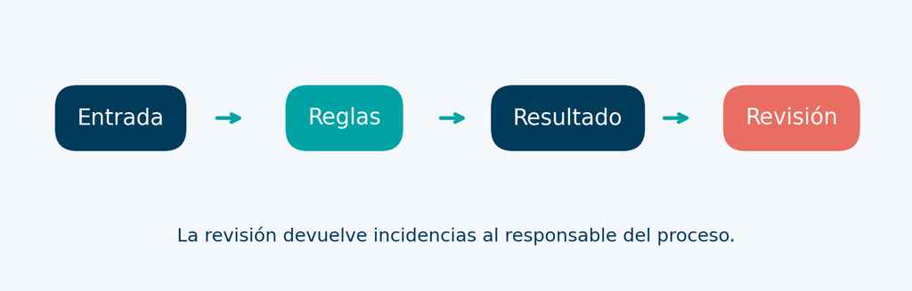

La **entrada** aporta datos. Las **reglas** especifican decisiones. El **resultado** debe poder verificarse. La **revisión** resuelve excepciones y puede modificar la especificación.

## Una especificación convierte intención en condiciones

«Limpiar los datos» admite muchas interpretaciones. Una especificación observable define condiciones concretas.

Para el laboratorio: identificador no vacío, importe decimal finito positivo con hasta dos decimales y año entero dentro de un conjunto permitido.

**Condición de salida**

Cada fila termina como aceptada o incidencia, con un motivo principal.

La repetición de un identificador en el mismo año se marca como duplicado después de validar sus campos.

## Scripts, RPA e IA resuelven problemas diferentes

| Enfoque | Cómo actúa | Limitación relevante |
| --- | --- | --- |
| Script | Ejecuta instrucciones sobre datos o servicios. | Depende del formato y del contrato de entrada. |
| RPA / automatización de interfaz | Opera botones, campos y pantallas. | Un cambio visual puede romper el flujo. |
| IA | Estima o genera una salida a partir de un modelo. | Puede equivocarse aunque la salida resulte convincente. |
| Combinación | Integra modelos con validaciones y revisión. | Exige controlar cada componente y su interacción. |

**Elección de mecanismo**

Si los datos ya están estructurados y existe una interfaz estable, un script puede operar directamente sobre ellos. Recurrir a una pantalla añade dependencia de la interfaz. Incorporar IA exige además evaluar sus respuestas.

## Determinismo y variación de resultados

Un proceso determinista aplica las mismas reglas a las mismas entradas y produce el mismo resultado funcional.

La reproducibilidad requiere además conservar configuración, versión del código y datos de referencia. Una fuente externa actualizada puede cambiar el resultado aunque el código sea idéntico.

**Dos resultados diferentes**

El resumen de importes debería repetirse.

La hora de ejecución cambiará. Por eso comparamos el contenido funcional por separado de los metadatos temporales.

## Quién inicia el trabajo y quién lo supervisa

| Modalidad | Inicio | Ejemplo |
| --- | --- | --- |
| Atendida | Una persona pulsa ejecutar. | El analista valida un listado recibido. |
| Programada | Un horario inicia la ejecución. | Preparar un resumen cada lunes. |
| Por evento | Una señal dispara el proceso. | Procesar un archivo cuando llega. |

La ejecución desatendida necesita reglas para avisar, detenerse y recuperar el trabajo. Un horario no garantiza que la entrada esté disponible.

## Qué gana una organización

La mejora puede consistir en reducir tiempo de manipulación, aplicar criterios consistentes o conservar evidencia. Cada beneficio necesita una medida.

Un proceso más rápido puede seguir produciendo resultados erróneos si utiliza una regla equivocada.

**Beneficio verificable**

Antes: cada analista decide qué hacer con el importe vacío.

Después: todos lo registran como incidencia y el responsable revisa el caso.

**Cómo demostrar la mejora**

Antes de comparar ejecuciones, fija qué mides: minutos de intervención humana, filas revisadas, incidencias detectadas o tiempo hasta entregar el resultado. Una medida útil conserva la misma definición antes y después.

## El coste total incluye más que ejecutar código

$$T_m(n)=n\,t_m\qquad T_a(n)=T_0+n\,t_a$$

$T_0$: preparación inicial. $t_m$: tiempo manual por registro. $t_a$: tiempo automatizado por registro, incluida la revisión media.

$$n^*=\frac{T_0}{t_m-t_a}\quad\text{si }t_m>t_a$$

Con $T_0=240$ minutos, $t_m=2$ y $t_a=0,1$, el equilibrio ocurre en $126,32$ registros: a partir de **127** registros, el modelo estima ahorro.

**Interpretación del modelo**

El equilibrio iguala los costes acumulados. Para obtener ahorro necesitamos superar ese punto. Si la revisión o el mantenimiento aumentan, debemos recalcular los tiempos antes de afirmar que la automatización compensa.

## Un ahorro aparente puede ocultar preparación

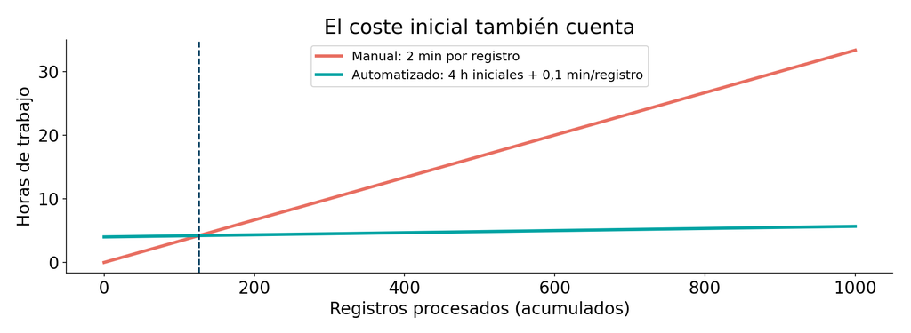

**Escenario ilustrativo**, no benchmark. La curva depende de los tiempos supuestos y de que las reglas permanezcan estables.

## Velocidad, calidad y cobertura

$$\text{Incidencias (\%)}=100\frac{N_{inc}}{N_{entrada}}$$

$$\text{Cobertura territorial (\%)}=100\frac{N_{ubicados}}{N_{aceptados}}$$

Cada indicador necesita un denominador explícito. Si es cero, devolvemos **sin base para calcular**, en lugar de inventar un porcentaje.

Una incidencia detectada muestra una condición incumplida. Su proporción no equivale a la tasa real de errores del sistema.

## Automatizar también multiplica los errores

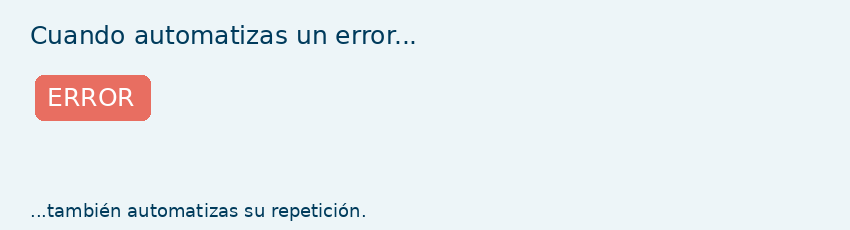

Una regla incorrecta aplicada a mil registros puede generar mil decisiones equivocadas. Por eso comprobamos primero casos pequeños con resultado conocido.

## El proyecto completo: observatorio territorial

El proyecto final podrá incorporar listados, depuración, correspondencia territorial, contexto estadístico, Excel e informes.

En este tema construimos el núcleo mínimo: **recibir registros, aplicar reglas y explicar el resumen**.

**Límite de interpretación**

Un importe publicado corresponde a un listado y una fecha de referencia.

No representa por sí mismo toda la deuda de un territorio ni la situación actual de una persona.

## El dato territorial necesita una correspondencia fiable

| Información | Papel en el proyecto |
| --- | --- |
| Listado de partida | Identificación e importe publicado, según sus campos. |
| Correspondencia territorial | Vinculación justificada con municipio o provincia. |
| Datos del INE | Contexto estadístico del territorio y periodo. |

El INE permite obtener información estadística y metadatos. **No asumimos que permita localizar directamente a un deudor por su NIF.**

Fuente: [Datos abiertos del INE](https://www.ine.es/datosabiertos/).

## Datos públicos y tratamiento responsable

La publicación de información y su reutilización son cuestiones diferentes. Para datos personales deben examinarse finalidad, base jurídica, minimización, exactitud, conservación y acceso.

En clase empleamos datos sintéticos y no enviamos identificadores reales a servicios externos.

**Decisión de diseño**

Los resultados de aula contienen identificadores ficticios.

Un despliegue con datos reales requiere revisar las fuentes, las condiciones aplicables y quién recibirá cada informe.

[RGPD, arts. 5 y 6](https://www.boe.es/doue/2016/119/L00001-00088.pdf).

## Qué exige leer la fuente tributaria

El artículo 95 bis de la Ley General Tributaria regula una publicación específica y prevé medidas contra la indexación y un periodo limitado de accesibilidad. Eso impide tratar su publicación como una autorización general para cualquier difusión posterior.

La fecha de referencia y las condiciones de inclusión importan al comparar ediciones. Una salida del listado **no demuestra por sí sola el pago**.

El laboratorio aplica reglas técnicas ficticias. No calcula quién cumple los requisitos legales de publicación.

[BOE · Ley 58/2003, art. 95 bis](https://www.boe.es/buscar/act.php?id=BOE-A-2003-23186#a95bis).

## Una tabla pequeña para entender todas las decisiones

| Fila | ID ficticio | Importe (texto) | Año | Decisión esperada |
| --- | --- | --- | --- | --- |
| 1 | DEMO-001 | 1200000.00 | 2025 | Aceptar. |
| 2 | DEMO-002 | 800000.00 | 2025 | Aceptar. |
| 3 | DEMO-003 | pendiente | 2025 | Importe inválido. |
| 4 | vacío | 700000.00 | 2025 | ID vacío. |
| 5 | DEMO-001 | 1200000.00 | 2025 | Duplicado. |
| 6 | DEMO-004 | 900000.00 | 2099 | Año inválido. |

**Por qué conservamos las seis filas**

Excluir una fila del cálculo no significa borrarla. La fila original y el motivo permiten revisar la decisión. El duplicado se reconoce por ID y año; su importe no contribuye una segunda vez al total.

## La entrada es una lista de registros

```python
registros = [
    {"id": "DEMO-001", "importe": "1200000.00", "anio": 2025},
    {"id": "DEMO-002", "importe": "800000.00", "anio": 2025},
]

print(registros[0]["importe"])  # texto: 1200000.00
```

La lista mantiene las filas. Cada diccionario relaciona nombres de campos con valores. El importe llega como texto y debe validarse antes de sumarlo.

## Una regla se expresa como una condición

```python
identificador = "   "

if not identificador.strip():
    estado = "id_vacio"
else:
    estado = "revisar_importe"

print(estado)  # id_vacio
```

`.strip()` elimina espacios de los extremos. La cadena resultante vacía se interpreta como falsa.

La condición codifica una regla observable. No comprueba la validez de un NIF ni la identidad de una entidad. Solo comprueba que el campo contiene texto. Convertir cualquier campo a texto puede ocultar entradas mal formadas.

## Por qué usamos Decimal para los importes

```python
from decimal import Decimal

importe = Decimal("1200000.00")
otro = Decimal("800000.00")
print(importe + otro)
# 2000000.00
```

El tipo `Decimal` permite trabajar con representación decimal. Construimos el número desde el **texto original**, evitando una conversión intermedia a `float`.

La representación exacta no valida el significado: también debemos rechazar valores no finitos, negativos o con precisión incompatible.

## Un contrato de importe evita interpretar formatos ambiguos

**Contrato de aula:** texto sin separadores de miles, punto decimal opcional y hasta dos cifras decimales. Límite: menos de un billón de euros.

| Entrada | Resultado | Motivo |
| --- | --- | --- |
| `"1200.50"` | Aceptada | Formato y valor válidos. |
| `"1.200,50"` | Incidencia | Formato fuera del contrato. |
| `"NaN"`, `"Infinity"` | Incidencia | No son importes finitos válidos. |
| `"-5"`, `"0"`, `"1.234"` | Incidencia | Signo, valor o decimales incompatibles. |

## Una función reúne una decisión comprobable

```python
def normalizar_id(valor):
    if not isinstance(valor, str):
        return None
    resultado = valor.strip()
    return resultado if resultado else None

assert normalizar_id(" DEMO-001 ") == "DEMO-001"
assert normalizar_id("  ") is None
```

Una función recibe una entrada y devuelve un resultado. Separar esta regla facilita probarla con casos pequeños y reutilizarla sin copiar condiciones.

**Lectura de la salida**

`None` indica que el valor no cumple el contrato. Así el llamador puede abrir una incidencia. Devolver una cadena vacía o convertir cualquier objeto a texto sin decidirlo antes haría menos clara la distinción entre ausencia y dato aceptado.

## El año también forma parte del contrato

```python
ANIOS_PERMITIDOS = {2024, 2025}

def anio_valido(valor):
    return (
        type(valor) is int
        and valor in ANIOS_PERMITIDOS
    )
```

El año permitido depende de la configuración de la práctica. No utilizamos el reloj del ordenador para cambiarlo sin avisar.

`type(valor) is int` excluye booleanos, que en Python se comportan como enteros en algunas operaciones. El texto `"2025"` requiere conversión previa explícita.

## La clave de duplicado necesita el periodo

```python
vistos = set()
clave = ("DEMO-001", 2025)

if clave in vistos:
    estado = "duplicado"
else:
    vistos.add(clave)
    estado = "aceptado"
```

Usamos `(identificador, año)`: una misma entidad puede aparecer en dos ediciones. El conjunto `vistos` pertenece a una ejecución y se reconstruye cada vez.

**Qué debe decidir el responsable**

Dos filas con la misma clave pueden ser una copia idéntica o un conflicto entre versiones. En esta práctica usamos copias idénticas. Con datos reales conservar el primer registro sin investigar el conflicto podría ocultar una corrección.

## El orden de las reglas cambia el motivo principal

| Orden | Regla | Estado si falla |
| --- | --- | --- |
| 1 | Existe un ID de texto no vacío. | `id_vacio` |
| 2 | El importe cumple el contrato. | `importe_invalido` |
| 3 | El año es un entero permitido. | `anio_invalido` |
| 4 | No existe una clave válida anterior. | `duplicado` |
| 5 | Se han superado todos los controles. | `aceptado` |

Cada fila recibe **un único estado principal**. Otros diseños pueden acumular motivos, pero deben documentarlo.

**Lectura de las frecuencias**

Un aumento del motivo ID vacío puede ocultar importes también inválidos en esas mismas filas. Este resumen sirve para gestionar el primer bloqueo. Un diagnóstico exhaustivo necesitaría conservar todos los motivos encontrados.

## Un bucle aplica la regla a todas las filas

```python
aceptados = []
incidencias = []

for fila in registros:
    # validar_fila devuelve una decisión explícita
    resultado = validar_fila(fila, vistos, ANIOS_PERMITIDOS)
    if resultado["estado"] == "aceptado":
        aceptados.append(resultado)
    else:
        incidencias.append(resultado)
```

Este fragmento ilustra el recorrido. La función completa y su contrato están en los notebooks y en `script_solucion.py`.

## Resultado esperado del primer recorrido

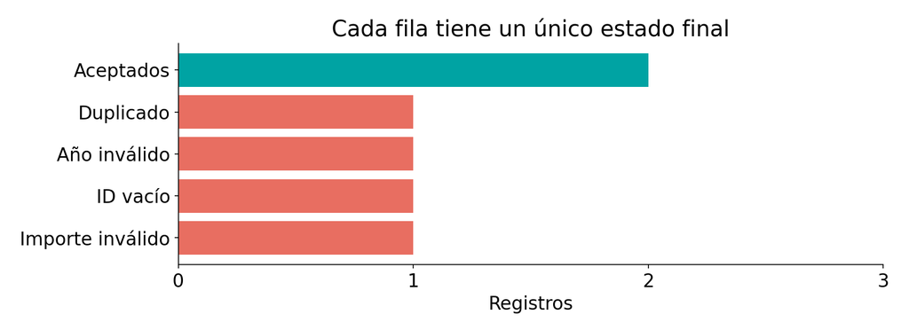

**6 entradas = 2 aceptados + 4 incidencias.** El importe aceptado es **2.000.000,00 €**.

## Un resumen requiere definir qué estamos sumando

```python
total = sum(
    (fila["importe"] for fila in aceptados),
    start=Decimal("0.00"),
)
print(total)  # 2000000.00
```

El valor inicial mantiene el tipo decimal incluso si no hay aceptados. Sumamos únicamente registros que superaron los controles. Un importe inválido no se sustituye por cero: queda en incidencias.

## La reconciliación comprueba que no perdemos filas

$$N_{entrada}=N_{aceptados}+N_{incidencias}$$

```python
assert len(registros) == len(aceptados) + len(incidencias)
assert total == Decimal("2000000.00")
```

La primera comprobación detecta filas perdidas o contadas dos veces. La segunda contrasta un ejemplo cuyo resultado conocemos. Ambas pueden pasar aunque exista otro error no cubierto.

**Alcance del control**

Conservar seis filas también sería compatible con aceptar dos veces el mismo registro y excluir otro por error. Por eso combinamos reconciliación, clave de unicidad y casos con una respuesta conocida.

## Una excepción no es una incidencia de negocio

| Situación | Tratamiento propuesto |
| --- | --- |
| Importe con texto fuera del contrato | Registrar incidencia y continuar con la siguiente fila. |
| Dos filas con la misma clave | Registrar el duplicado para revisión. |
| La entrada no es una lista | Detener la ejecución por contrato incompatible. |
| Falta una regla o aparece un fallo de programación | Detener y diagnosticar. |

Capturar cualquier error y continuar puede producir un informe incompleto que parece correcto.

**Continuar con criterio**

El proceso puede seguir cuando conoce el tipo de problema y conserva evidencia suficiente. Si desconoce la causa, continuar puede ocultar una ejecución incompleta. La decisión de detenerse debe formar parte del diseño.

## Una ejecución debe dejar evidencia suficiente

La trazabilidad permite responder qué datos y reglas produjeron un resultado. En el laboratorio conservamos número de fila, estado y motivo.

En el proyecto completo añadiremos origen, edición, versión de reglas y momento de ejecución.

**Ejemplo de evidencia**

Fila 3 · `importe_invalido`

Entrada: `pendiente`

Motivo: formato no admitido.

No hace falta registrar identificadores personales en cada mensaje del sistema.

## Repetir el cálculo y repetir una acción son cosas distintas

Una función sin efectos externos puede ejecutarse dos veces y devolver el mismo resumen.

Una acción como enviar un correo puede duplicarse aunque el cálculo sea reproducible. La **idempotencia** describe una operación cuyo efecto final no cambia al repetirla.

**En la práctica**

Recalculamos desde la entrada y creamos un conjunto `vistos` nuevo.

No acumulamos resultados en listas globales ni realizamos envíos reales.

## Una prueba pequeña puede revelar un límite mal definido

| Caso | Resultado que esperamos |
| --- | --- |
| Lista vacía | Cero aceptados, total decimal cero, tasa sin base. |
| Todas las filas inválidas | Cero aceptados y una incidencia por entrada. |
| Mismo ID en años distintos permitidos | Dos registros aceptados. |
| Año `True` o texto `"2025"` | Incidencia de año. |
| Segunda ejecución con los mismos datos | Mismo resultado funcional y entrada intacta. |

## La supervisión humana tiene una responsabilidad concreta

El proceso separa trabajo repetible de decisiones pendientes. Una persona revisa motivos, contrasta la fuente y decide si corrige, excluye o solicita información.

La decisión y su justificación deben quedar vinculadas a la incidencia original.

**Ejemplo**

Dos registros comparten ID y año, pero tienen importes diferentes.

El script detecta el conflicto. El responsable debe decidir qué fuente y versión son válidas.

## Laboratorio: observar, construir y comprobar

| Tramo | Actividad | Entregable |
| --- | --- | --- |
| Guiado | Ejecutar el ejemplo completo y explicar sus estados. | Resumen de seis filas. |
| Ejercicios 1–4 | Reconocer el contrato y formular reglas. | Predicciones y funciones pequeñas. |
| Ejercicios 5–8 | Clasificar, reconciliar y calcular indicadores. | Resultados contrastados con salidas esperadas. |
| Ejercicios 9–12 | Repetir, revisar límites y justificar el resultado. | Evidencia técnica e interpretación. |

## Demostración: primero predecimos la salida

Antes de ejecutar, responde con tu pareja:

1. ¿Qué filas contribuyen al total?
2. ¿Qué ocurre con un ID repetido en otro año permitido?
3. ¿Qué motivo recibe una fila con ID vacío e importe inválido?
4. ¿Qué porcentaje tiene cuatro incidencias entre seis entradas?

Respuestas: filas 1 y 2 · puede aceptarse en otro año · `id_vacio` · aproximadamente 66,67 %. Sigue siendo un ejemplo de controles técnicos.

## Qué puede concluir el informe de aula

**Conclusión respaldada**

Dos registros sintéticos cumplen las reglas técnicas y suman dos millones de euros. Cuatro filas requieren revisión por los motivos indicados.

El resultado describe esta entrada y esta configuración.

**Conclusión sin respaldo**

«La deuda de una provincia ha bajado» o «estas entidades ya han pagado».

No tenemos territorios, histórico comparable ni evidencia de pagos en este laboratorio.

## Criterios para revisar el trabajo

| Criterio | Qué demuestra comprensión |
| --- | --- |
| Especificación | Explica cada estado y el orden de reglas. |
| Ejecución | Obtiene el resultado desde un kernel limpio. |
| Validación | Comprueba totales, filas y casos límite. |
| Trazabilidad | Conserva motivos sin perder las entradas. |
| Interpretación | Limita las conclusiones a la evidencia disponible. |

Una salida correcta sin explicación no permite saber si el criterio se ha entendido.

## Cómo se conecta con el tema siguiente

Ya tenemos una descripción ejecutable de un proceso mínimo. El siguiente bloque estudiará **qué procesos merece la pena automatizar y cómo priorizarlos**.

Trabajaremos frecuencia, estabilidad, excepciones, impacto y viabilidad con más detalle.

**Pregunta de salida**

Explica una tarea de tu trabajo usando entrada, regla, salida y revisión.

Después identifica una decisión que todavía necesita aclarar una persona.

## Fuentes técnicas y uso de los recursos

| Recurso | Referencia |
| --- | --- |
| Python: condiciones, funciones y excepciones | [Tutorial oficial](https://docs.python.org/3/tutorial/) |
| Representación decimal | [Documentación de Decimal](https://docs.python.org/3/library/decimal.html) |
| Quarto y notas docentes | [Reveal.js en Quarto](https://quarto.org/docs/presentations/revealjs/) |
| Contexto estadístico futuro | [Datos abiertos del INE](https://www.ine.es/datosabiertos/) |

Todos los diagramas, gráficos, la portada y el GIF de este paquete son originales. Las cifras son ficticias o supuestos ilustrativos.

## Fuentes para el marco legal

**Lectura general, sujeta al uso concreto y a posibles cambios normativos.**

- [Ley 58/2003, General Tributaria, art. 95 bis](https://www.boe.es/buscar/act.php?id=BOE-A-2003-23186#a95bis): publicidad y condiciones del listado.
- [RGPD, texto oficial, arts. 5 y 6](https://www.boe.es/doue/2016/119/L00001-00088.pdf): principios y licitud del tratamiento.
- [AEAT: publicidad de incumplimiento relevante](https://sede.agenciatributaria.gob.es/Sede/informacion-institucional/puede-interesar/analisis/2024/abril/1/publicidad-situaciones-incumplimiento-relevante-obligaciones-tributarias.html): contexto institucional.

Fecha de revisión del material: **2 de noviembre de 2026**.